# Project Business Statistics: E-news Express

## Problem Statement

The advent of e-news, or electronic news, portals has offered us a great opportunity to quickly get updates on the day-to-day events occurring globally. The information on these portals is retrieved electronically from online databases, processed using a variety of software, and then transmitted to the users. There are multiple advantages of transmitting new electronically, like faster access to the content and the ability to utilize different technologies such as audio, graphics, video, and other interactive elements that are either not being used or aren’t common yet in traditional newspapers.

E-news Express, an online news portal, aims to expand its business by acquiring new subscribers. With every visitor to the website taking certain actions based on their interest, the company plans to analyze these actions to understand user interests and determine how to drive better engagement. The executives at E-news Express are of the opinion that there has been a decline in new monthly subscribers compared to the past year because the current webpage is not designed well enough in terms of the outline & recommended content to keep customers engaged long enough to make a decision to subscribe.

[Companies often analyze user responses to two variants of a product to decide which of the two variants is more effective. This experimental technique, known as A/B testing, is used to determine whether a new feature attracts users based on a chosen metric.]

## Objectives

The design team of the company has researched and created a new landing page that has a new outline & more relevant content shown compared to the old page. In order to test the effectiveness of the new landing page in gathering new subscribers, the Data Science team conducted an experiment by randomly selecting 100 users and dividing them equally into two groups. The existing landing page was served to the first group (control group) and the new landing page to the second group (treatment group). Data regarding the interaction of users in both groups with the two versions of the landing page was collected. Being a data scientist in E-news Express, you have been asked to explore the data and perform a statistical analysis (at a significance level of 5%) to determine the effectiveness of the new landing page in gathering new subscribers for the news portal by answering the following questions:

Do the users spend more time on the new landing page than on the existing landing page? Is the conversion rate (the proportion of users who visit the landing page and get converted) for the new page greater than the conversion rate for the old page? Does the converted status depend on the preferred language? Is the time spent on the new page the same for the different language users?

## Import all the necessary libraries

```python
# import libraries for data manipulation
import numpy as np
import pandas as pd

# import libraries for data visualization
import matplotlib.pyplot as plt
import seaborn as sns

# import libraries for warnings ignoring
import warnings
warnings.filterwarnings('ignore')
%matplotlib inline

# import libraries for probability distributions and statistical functions
import scipy.stats as stats
```

## Reading the Data into a DataFrame

```python
from google.colab import drive

# Mount Google Drive
drive.mount('/content/drive')

# Access files in your Google Drive by specifying the path
file_path = '/content/drive/My Drive/MastersDataScience/abtest.csv'
```

```python
# read the data
df = pd.read_csv(file_path)
# returns the first 5 rows
df.head()
```

|  | user_id | group | landing_page | time_spent_on_the_page | converted | language_preferred |
| --- | --- | --- | --- | --- | --- | --- |
| 0 | 546592 | control | old | 3.48 | no | Spanish |
| 1 | 546468 | treatment | new | 7.13 | yes | English |
| 2 | 546462 | treatment | new | 4.40 | no | Spanish |
| 3 | 546567 | control | old | 3.02 | no | French |
| 4 | 546459 | treatment | new | 4.75 | yes | Spanish |

## Exploratory Data Analysis

```python
print("The number of rows in provided set are: " +
      "\033[1m" + str(df.shape[0]) + "\033[0m" +
      "\nThe number of columns in provided dataset are: \033[1m" + str(df.shape[1]) + "\033[0m" + "\n")
print("\033[1mThe datatypes in provided dataset: \033[0m")
print(df.info())
print("\n")
print("\033[1mThe sum of null values in each column: \033[0m")
print(df.isnull().sum())
print("\n")
print("\033[1mHere is the statistical summary of provided data:\033[0m")
print(df.describe())
print("\n")
print("The min time spent (minutes) on the landing page is: " +
      "\033[1m" + str(df['time_spent_on_the_page'].min()) + "\033[0m" +
      "\nThe max time spent (minutes) on the landing page is: " +
      "\033[1m" + str(df['time_spent_on_the_page'].max()) + "\033[0m")
```

```
The number of rows in provided set are: 100
The number of columns in provided dataset are: 6

The datatypes in provided dataset:
<class 'pandas.core.frame.DataFrame'>
RangeIndex: 100 entries, 0 to 99
Data columns (total 6 columns):
 #   Column                  Non-Null Count  Dtype
---  ------                  --------------  -----
 0   user_id                 100 non-null    int64
 1   group                   100 non-null    object
 2   landing_page            100 non-null    object
 3   time_spent_on_the_page  100 non-null    float64
 4   converted               100 non-null    object
 5   language_preferred      100 non-null    object
dtypes: float64(1), int64(1), object(4)
memory usage: 4.8+ KB
None


The sum of null values in each column:
user_id                   0
group                     0
landing_page              0
time_spent_on_the_page    0
converted                 0
language_preferred        0
dtype: int64


Here is the statistical summary of provided data:
             user_id  time_spent_on_the_page
count     100.000000              100.000000
mean   546517.000000                5.377800
std        52.295779                2.378166
min    546443.000000                0.190000
25%    546467.750000                3.880000
50%    546492.500000                5.415000
75%    546567.250000                7.022500
max    546592.000000               10.710000


The min time spent (minutes) on the landing page is: 0.19
The max time spent (minutes) on the landing page is: 10.71
```

### Univariate Analysis

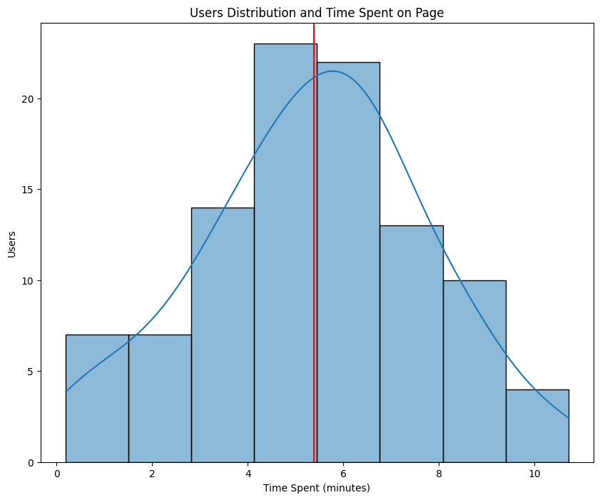

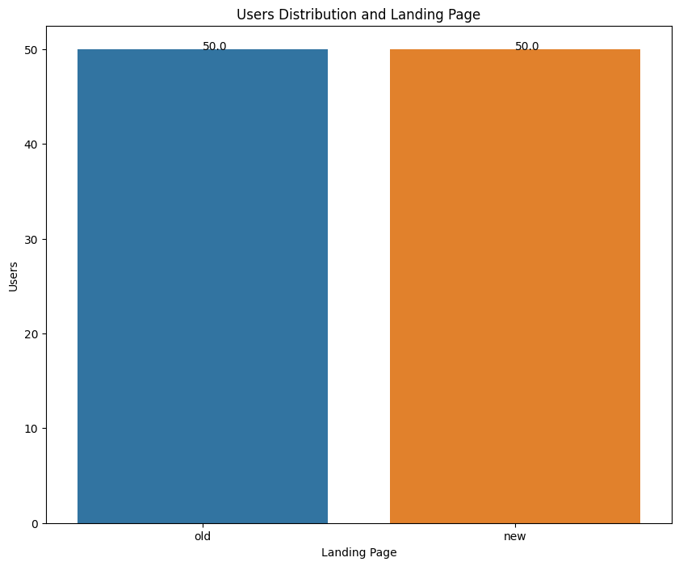

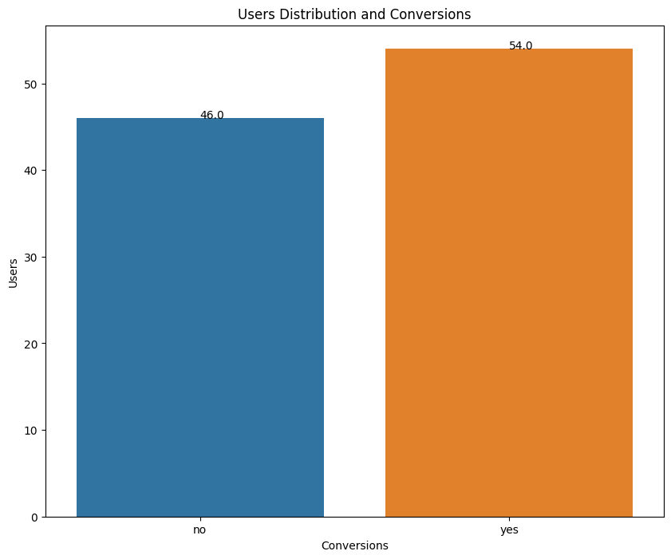

```python
# Users Distribution & Time Spent on Page

plt.figure(figsize=(10,8))
sns.histplot(data=df, x='time_spent_on_the_page', kde=True)
plt.axvline(df['time_spent_on_the_page'].mean(), color='r')
plt.title('Users Distribution and Time Spent on Page')
plt.xlabel('Time Spent (minutes)')
plt.ylabel('Users')
plt.show()

# Users Distribution & Landing Page Distribution

plt.figure(figsize=(10,8))
splot = sns.countplot(data=df, x ='landing_page')
for p in splot.patches:
  splot.annotate(format(p.get_height(), '.1f'), (p.get_x() + p.get_width()/ 2 , p.get_height()))
plt.title("Users Distribution and Landing Page")
plt.xlabel('Landing Page')
plt.ylabel('Users')
plt.show()

# Users Distribution & Conversion Distribution

plt.figure(figsize=(10,8))
splot = sns.countplot(data=df, x ='converted')
for p in splot.patches:
  splot.annotate(format(p.get_height(), '.1f'), (p.get_x() + p.get_width()/ 2 , p.get_height()))
plt.title("Users Distribution and Conversions")
plt.xlabel('Conversions')
plt.ylabel('Users')
plt.show()
```

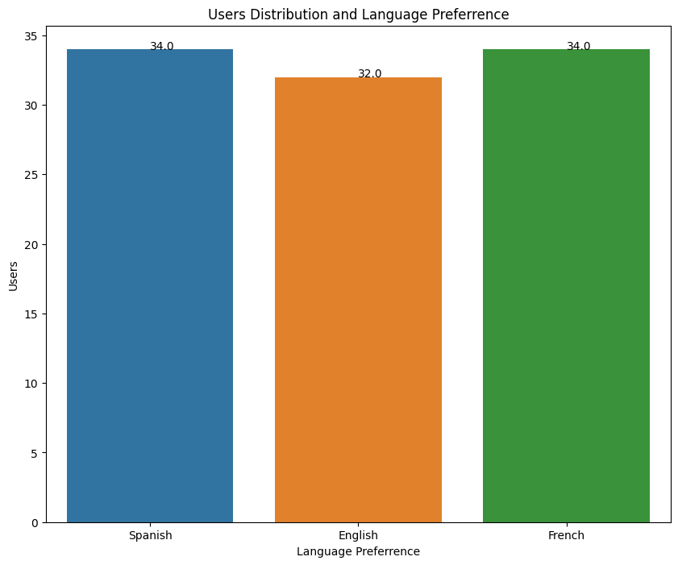

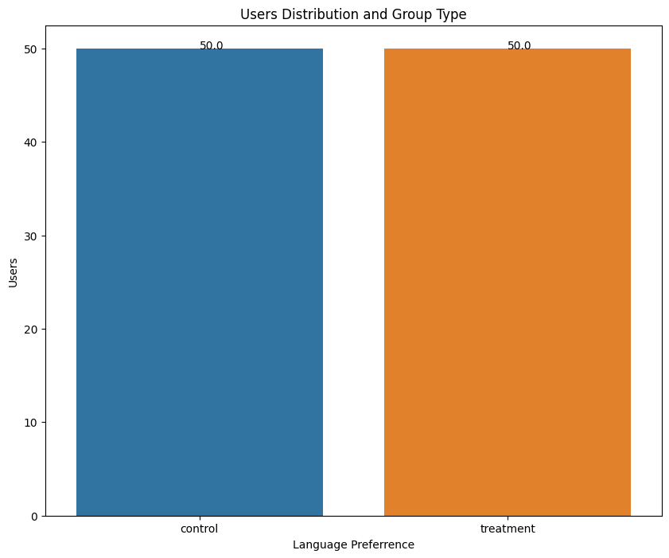

```python
# Users Distribution & Language Preference Distribution

plt.figure(figsize=(10,8))
splot = sns.countplot(data=df, x ='language_preferred')
for p in splot.patches:
  splot.annotate(format(p.get_height(), '.1f'), (p.get_x() + p.get_width()/ 2 , p.get_height()))
plt.title("Users Distribution and Language Preferrence")
plt.xlabel('Language Preferrence')
plt.ylabel('Users')
plt.show()

# Users Distribution & Group Type

plt.figure(figsize=(10,8))
splot = sns.countplot(data=df, x ='group')
for p in splot.patches:
  splot.annotate(format(p.get_height(), '.1f'), (p.get_x() + p.get_width()/ 2 , p.get_height()))
plt.title("Users Distribution and Group Type")
plt.xlabel('Language Preferrence')
plt.ylabel('Users')
plt.show()
```

### Bivariate Analysis

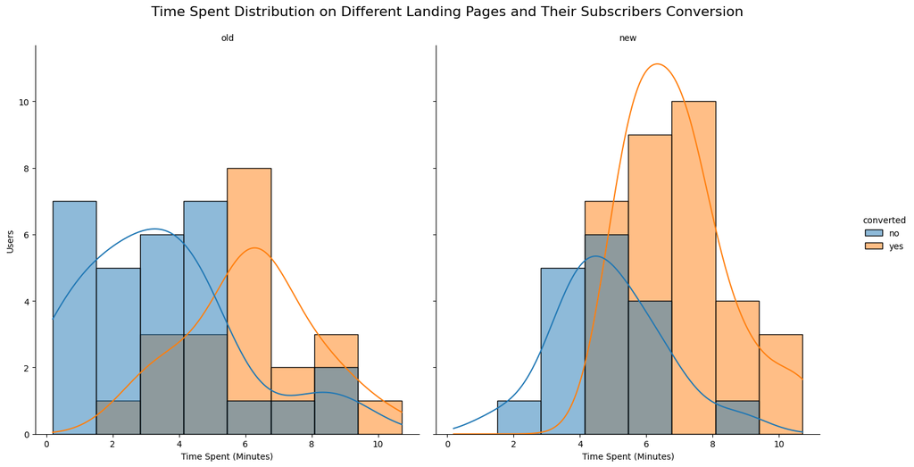

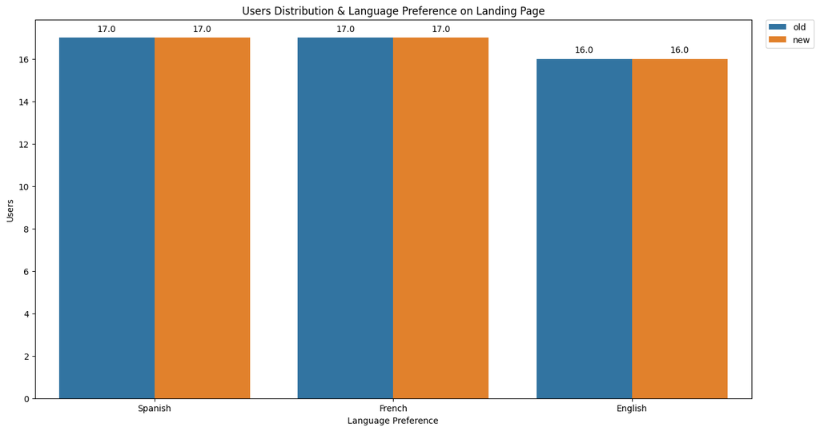

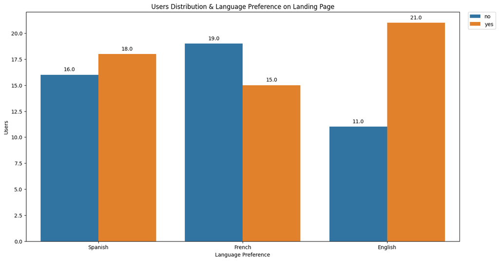

```python
# Time Spent Distribution on Different Landing Pages & Conversion Statistics

dfplot = sns.displot(data=df, x='time_spent_on_the_page', col='landing_page', hue='converted', kind='hist', kde=True)
dfplot.fig.set_size_inches(15,8)
dfplot.fig.subplots_adjust(top=0.9)
dfplot.fig.suptitle('Time Spent Distribution on Different Landing Pages and Their Subscribers Conversion', fontsize=16)
dfplot.set_axis_labels('Time Spent (Minutes)', 'Users')
dfplot.set_titles(col_template="{col_name}")
plt.show()

# Users Distribution & Language Preference on Landing Page

plt.figure(figsize=(15, 8))
cplot = sns.countplot(data=df, x ='language_preferred',hue='landing_page', order=df['language_preferred'].value_counts().index)
for i in cplot.patches:
  cplot.annotate(format(i.get_height(), '.1f'), (i.get_x() + i.get_width() / 2., i.get_height()),  ha = 'center', va = 'center', xytext = (0, 10), textcoords = 'offset points')
plt.title("Users Distribution & Language Preference on Landing Page")
plt.xlabel('Language Preference')
plt.ylabel('Users')
plt.legend(bbox_to_anchor=(1.02, 1), loc='upper left', borderaxespad=0)
plt.show()

# Users Distribution & Language Preference for Conversions Statistics

plt.figure(figsize=(15, 8))
cplot = sns.countplot(data=df, x ='language_preferred',hue='converted', order=df['language_preferred'].value_counts().index)
for i in cplot.patches:
  cplot.annotate(format(i.get_height(), '.1f'), (i.get_x() + i.get_width() / 2., i.get_height()),  ha = 'center', va = 'center', xytext = (0, 10), textcoords = 'offset points')
plt.title("Users Distribution & Language Preference on Landing Page")
plt.xlabel('Language Preference')
plt.ylabel('Users')
plt.legend(bbox_to_anchor=(1.02, 1), loc='upper left', borderaxespad=0)
plt.show()
```

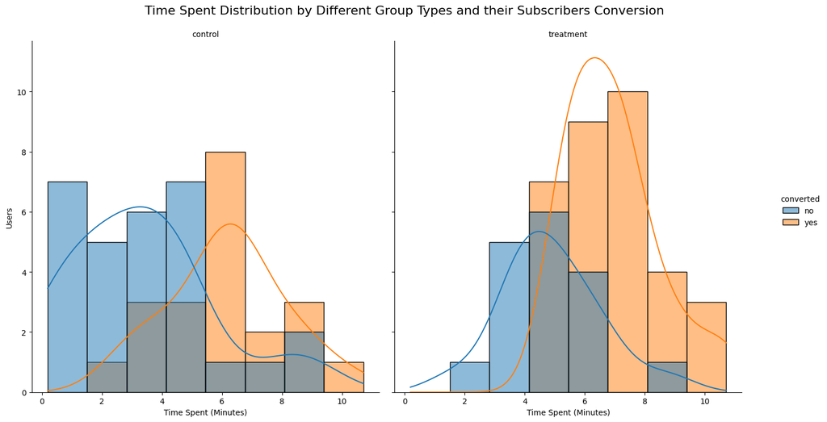

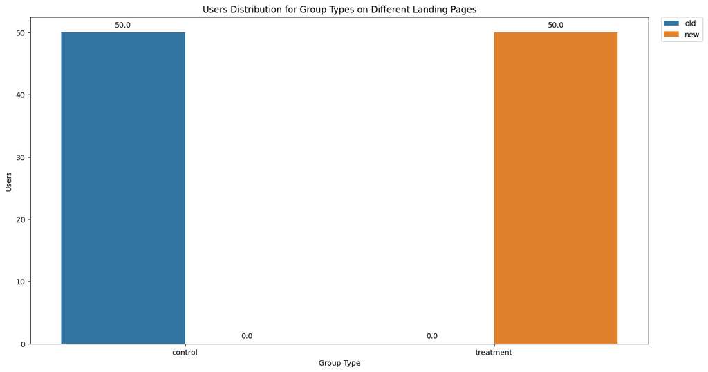

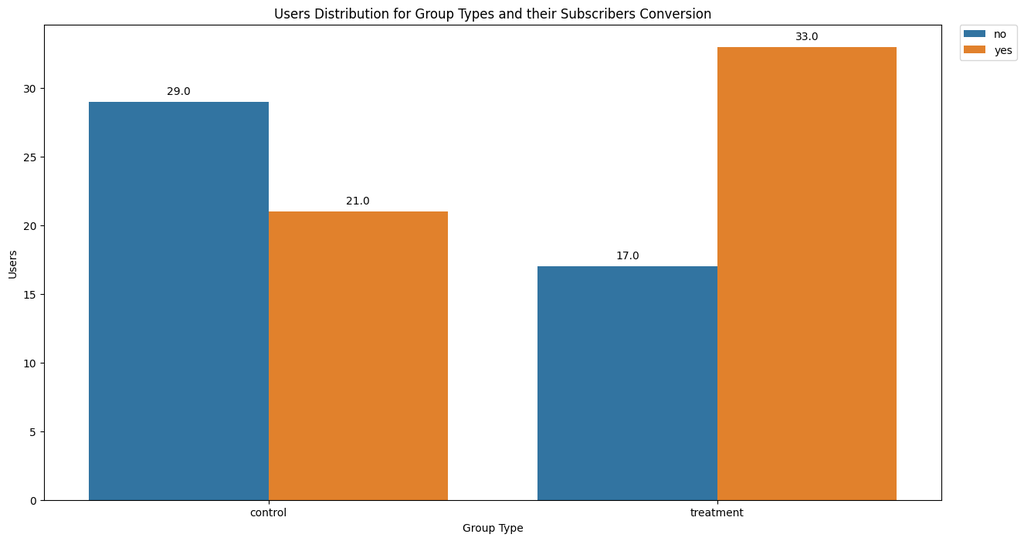

```python
# Time Spent Distribution on Different Landing Pages & Conversion Statistics

dfplot = sns.displot(data=df, x='time_spent_on_the_page', col='group', hue='converted', kind='hist', kde=True)
dfplot.fig.set_size_inches(15,8)
dfplot.fig.subplots_adjust(top=0.9)
dfplot.fig.suptitle('Time Spent Distribution by Different Group Types and their Subscribers Conversion', fontsize=16)
dfplot.set_axis_labels('Time Spent (Minutes)', 'Users')
dfplot.set_titles(col_template="{col_name}")
plt.show()

# Users Distribution & Group Type on Landing Page

plt.figure(figsize=(15, 8))
cplot = sns.countplot(data=df, x ='group',hue='landing_page', order=df['group'].value_counts().index)
for i in cplot.patches:
  cplot.annotate(format(i.get_height(), '.1f'), (i.get_x() + i.get_width() / 2., i.get_height()),  ha = 'center', va = 'center', xytext = (0, 10), textcoords = 'offset points')
plt.title("Users Distribution for Group Types on Different Landing Pages")
plt.xlabel('Group Type')
plt.ylabel('Users')
plt.legend(bbox_to_anchor=(1.02, 1), loc='upper left', borderaxespad=0)
plt.show()

# Users Distribution & Group Type for Conversions Statistics

plt.figure(figsize=(15, 8))
cplot = sns.countplot(data=df, x ='group',hue='converted', order=df['group'].value_counts().index)
for i in cplot.patches:
  cplot.annotate(format(i.get_height(), '.1f'), (i.get_x() + i.get_width() / 2., i.get_height()),  ha = 'center', va = 'center', xytext = (0, 10), textcoords = 'offset points')
plt.title("Users Distribution for Group Types and their Subscribers Conversion")
plt.xlabel('Group Type')
plt.ylabel('Users')
plt.legend(bbox_to_anchor=(1.02, 1), loc='upper left', borderaxespad=0)
plt.show()
```

## 1. Do the users spend more time on the new landing page than the existing landing page?

### Visual Analysis

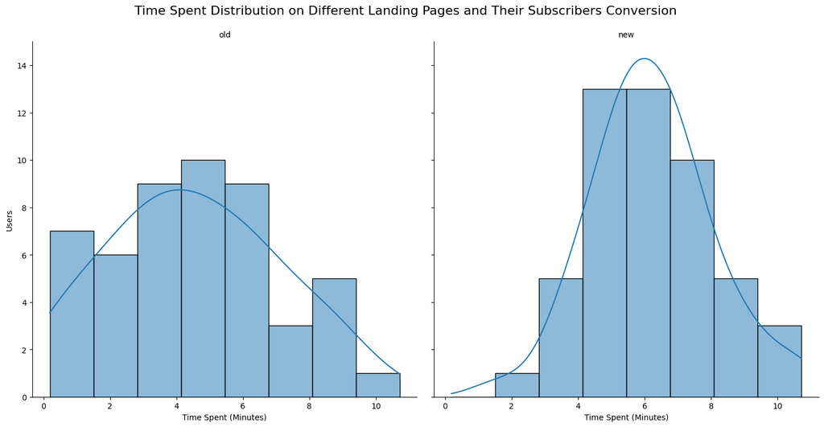

```python
dfplot = sns.displot(data=df, x='time_spent_on_the_page', col='landing_page', kind='hist', kde=True)
dfplot.fig.set_size_inches(15,8)
dfplot.fig.subplots_adjust(top=0.9)
dfplot.fig.suptitle('Time Spent Distribution on Different Landing Pages and Their Subscribers Conversion', fontsize=16)
dfplot.set_axis_labels('Time Spent (Minutes)', 'Users')
dfplot.set_titles(col_template="{col_name}")
plt.show()
```

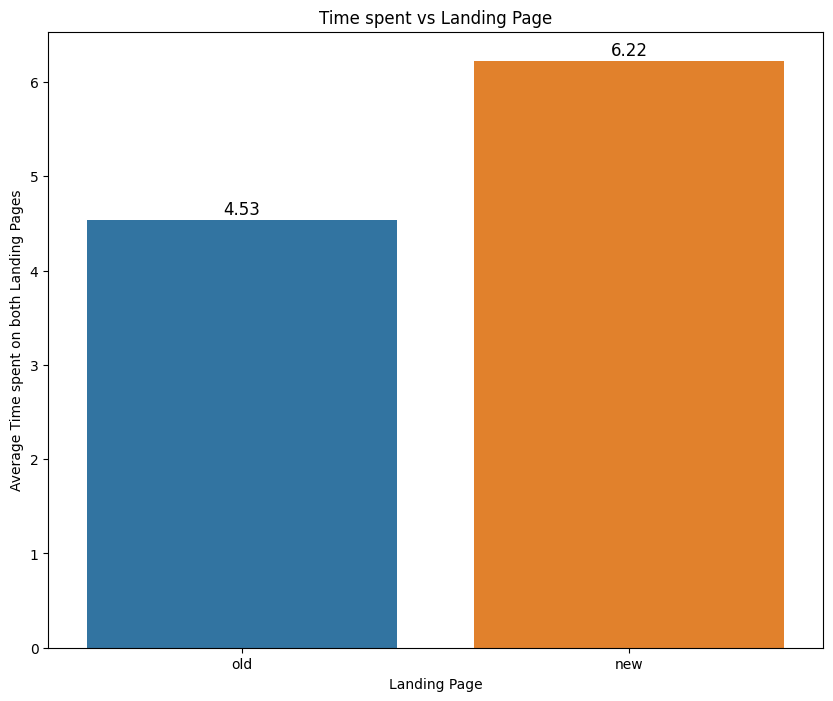

```python
plt.figure(figsize=(10,8))
bplot=sns.barplot(data=df, x='landing_page', y='time_spent_on_the_page',ci=None)
for bar in bplot.patches:
    bplot.annotate(format(bar.get_height(), '.2f'),
                   (bar.get_x() + bar.get_width() / 2,
                    bar.get_height()), ha='center', va='center',
                   size=12, xytext=(0, 8),
                   textcoords='offset points')
plt.title('Time spent vs Landing Page')
plt.xlabel('Landing Page')
plt.ylabel('Average Time spent on both Landing Pages')
plt.show()
```

### Step 1: Null and Alternate Hypotheses

The null and alternative hypotheses can be formulated as:

> $H_0$: The mean time spent on the new landing page is less than or equal to the mean time spent on the old landing page.

against the alternate hypothesis

> $H_a$: The mean time spent on the new landing page is greater than the mean time spent on the old landing page.

Let μ1 and μ2 be the mean time spent on the new landing page and the mean time spent on the old landing page

Mathematically, the above-formulated hypotheses can be written as:

> $H_0$: μ1<=μ2

against the alternate hypothesis

> $H_a$: μ1>μ2

### Step 2: Appropriate Test

As per given information, we'll move forward with Two Sample Independent T-test for equality of means with unequal standard deviation

### Step 3: Significance Level

Given significance level is 0.05

### Step 4: Data Collection and Preperation

```python
df_new = df[ df["landing_page"] == "new"]
df_old = df[ df["landing_page"] == "old"]
μ1, μ2 = df_new["time_spent_on_the_page"].mean() , df_old["time_spent_on_the_page"].mean()
std1, std2 = df_new["time_spent_on_the_page"].std() , df_old["time_spent_on_the_page"].std()
print("μ1, μ2, std1, std2:", str(round(μ1,2)) +",", str(round(μ2,2)) + ",", str(round(std1,2)) + "," , str(round(std2,2)))
```

```
μ1, μ2, std1, std2: 6.22, 4.53, 1.82, 2.58
```

### Step 5: p-value

```python
from scipy.stats import ttest_ind

#finding the p-value
test_stat, p_value = ttest_ind(df_new["time_spent_on_the_page"], df_old["time_spent_on_the_page"], \
                               equal_var = False, alternative = 'greater')
print('The p-value is: ' + "\033[1m" + str(p_value) + "\033[0m")
```

```
The p-value is: 0.0001392381225166549
```

### Step 6: Compare the p-value with $\alpha$

```python
print('The p-value is ', p_value, 'and the significance level alpha is 0.05\n')


if p_value < 0.05:
    print(f'As the p-value is less than the level of significance, we reject the null hypothesis.')
else:
    print(f'As the p-value is greater than the level of significance, we can not reject the null hypothesis.')
```

```
The p-value is  0.0001392381225166549 and the significance level alpha is 0.05

As the p-value is less than the level of significance, we reject the null hypothesis.
```

### Step 7: Draw inference

As the p-value (0.00014) is less than the significance level, we can reject the null hypothesis. Hence, we do have enough evidence to support the claim that the mean time spent on the new landing page is higher tha mean time spent on the old landing page

## 2. Is the conversion rate (the proportion of users who visit the landing page and get converted) for the new page greater than the conversion rate for the old page?

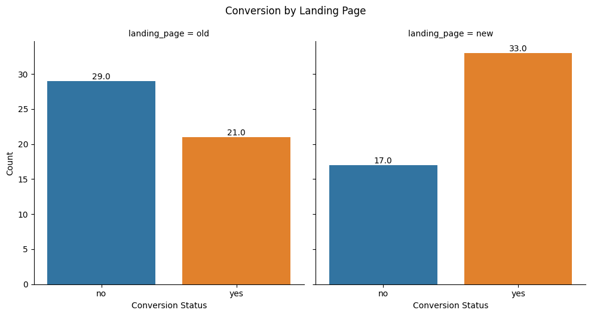

```python
plt.figure(figsize=(15,8))
cnvplt = sns.catplot(data=df, x='converted', col='landing_page', kind='count',ci=None)

ax1 = cnvplt.axes[0][0]
ax2 = cnvplt.axes[0][1]

bars = ax1.patches

for i in bars:
    height = i.get_height()
    ax1.text(i.get_x() + i.get_width()/2.0, height, '%.1f' % height, ha='center', va='bottom')

bars = ax2.patches
for i in bars:
    height = i.get_height()
    ax2.text(i.get_x() + i.get_width()/2.0, height, '%.1f' % height, ha='center', va='bottom')

cnvplt.set_xlabels("Conversion Status")
cnvplt.set_ylabels("Count")
cnvplt.fig.suptitle("Conversion by Landing Page", y=1.05)

plt.show()
```

Conversion Percentage - Old Landing Page: 42.0% Conversion Percentage - New Landing Page: 66.0%

### Step 1: Define the null and alternate hypotheses

- H0 : Null Hypothesis - The conversion rate for the new landing page is the same as the conversion rate for the old page
- Ha : The conversion rate for the new landing page is greater than the conversion rate for the old page

Let c1 and c2 be the conversion rates for the new and old landing pages respectively

- H0 : c1 = c2
- Ha : c1 > c2

### Step 2: Select Appropriate test

In order to test the proportions, a Two Proportion Z-test is selected.

### Step 3: Decide the significance level

The significance level is set at 0.05

### Step 4: Collect and prepare data

```python
conversion_new = float(df_new[df["converted"]=="yes"].count()["group"])
c1 = float(round(conversion_new/50, 2))
conversion_old = float(df_old[df["converted"]=="yes"].count()["group"])
c2 = float(round(conversion_old/50, 2))

print('The conversion rates for the new and old landing pages are', c1, 'and', c2, 'respectively.')
```

```
The conversion rates for the new and old landing pages are 0.66 and 0.42 respectively.
```

### Step 5: Calculate the p-value

```python
from statsmodels.stats.proportion import proportions_ztest
stat, pval = proportions_ztest([conversion_new, conversion_old], [50,50], alternative = 'larger')

print('The p-value is ', str(pval),)
```

```
The p-value is  0.008026308204056278
```

### Step 6: Compare the p-value with $\alpha$

```python
print('The p-value is ', str(pval), 'and the significance level alpha is 0.05')
```

```
The p-value is  0.008026308204056278 and the significance level alpha is 0.05
```

### Step 7: Draw inference

Given a p-value of 0.008, which is lower than the chosen significance level of 0.05, we can reject the null hypothesis. Consequently, we have sufficient evidence to support the claim that the conversion rate for the new landing page is higher than the conversion rate for the old landing page.

## 3. Is the conversion and preferred language are independent or related?

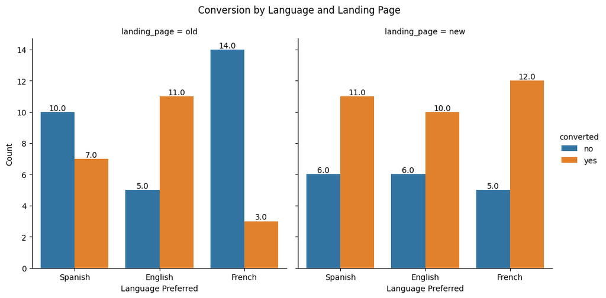

```python
plt.figure(figsize=(15,8))
cnvplt = sns.catplot(data=df, x='language_preferred',hue='converted', col='landing_page', kind='count', ci=None)

ax1 = cnvplt.axes[0][0]
ax2 = cnvplt.axes[0][1]

bars = ax1.patches
for i in bars:
    height = i.get_height()
    ax1.text(i.get_x() + i.get_width()/2.0, height, '%.1f' % height, ha='center', va='bottom')

bars = ax2.patches
for i in bars:
    height = i.get_height()
    ax2.text(i.get_x() + i.get_width()/2.0, height, '%.1f' % height, ha='center', va='bottom')

cnvplt.set_xlabels("Language Preferred")
cnvplt.set_ylabels("Count")
cnvplt.fig.suptitle("Conversion by Language and Landing Page", y=1.05)

plt.show()
```

### Step 1: Define the null and alternate hypotheses

- H0 : Null Hypothesis - The conversion is independent of the preferred language
- Ha : The conversion is dependent on the preferred language

### Step 2: Select Appropriate test

Since this deals with the dependence of two categorical variables, the Chi-Square test for independence is used.

### Step 3: Decide the significance level

The significance level is set at 0.05

### Step 4: Collect and prepare data

```python
#Creating a contingency table

Conversion_language = pd.crosstab(df.converted, df.language_preferred).rename_axis(None,axis=1).reset_index()
Conversion_language
```

|  | converted | English | French | Spanish |
| --- | --- | --- | --- | --- |
| 0 | no | 11 | 19 | 16 |
| 1 | yes | 21 | 15 | 18 |

### Step 5: Calculate the p-value

```python
from scipy.stats import chi2_contingency

#finding the p-value
chi, p_value, dof, expected = chi2_contingency(Conversion_language.drop('converted', axis = 1))
p_value
```

```
0.21298887487543447
```

### Step 6: Compare the p-value with $\alpha$

```python
print('The p-value is ', p_value, 'and the significance level alpha is 0.05')
```

```
The p-value is  0.21298887487543447 and the significance level alpha is 0.05
```

### Step 7: Draw inference

With a p-value of 0.21, which exceeds the significance level of 0.05, we cannot reject the null hypothesis. Consequently, we lack sufficient evidence to substantiate the assertion that the conversion rate is dependent on the preferred language.

## 4. Is the time spent on the new page same for the different language users?

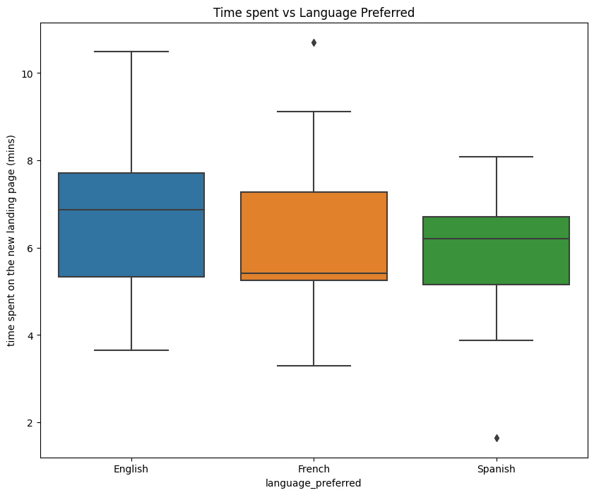

```python
plt.figure(figsize=(10,8))
sns.boxplot(x="language_preferred", y="time_spent_on_the_page",\
            data=df_new.sort_values("language_preferred", ascending = True));
plt.title('Time spent vs Language Preferred')
plt.ylabel("time spent on the new landing page (mins)")
plt.show()
```

### Step 1: Null and Alternate Hypotheses

Let μ1, μ2, μ3 be the mean time spent on the new landing page for the different language users - English, French and Spanish respectively.

- H0 : Null Hypothesis - The time spent on the new landing page is the same for all languages μ1 = μ2 = μ3
- Ha : At least one of μ1, μ2, μ3 is different from the rest

### Step 2: Appropriate Test

Since we are dealing with the testing of different means, Analysis of Variance (ANOVA) test is selected.

### Step 3: Significance Level

The significance level is set at 0.05

### Step 4: Collection and Preparation of data

Next,the normality and equality of variance assumptions need to be checked,

- For testing normality, Shapiro-Wilk's test is used
- For equality of varince, Levene's test is used

Shapiro Wilk's Test

- H0: Null Hypothesis - Time spent on the new landing page follows a normal distribution
- Ha: Alternate Hypothesis - Time spent on the new landing page does not follow a normal distribution

```python
# find the p-value

w, p_value = stats.shapiro(df_new['time_spent_on_the_page'])
print('The p-value is', p_value)
```

```
The p-value is 0.8040016293525696
```

Given the large p-value, we do not reject the null hypothesis that the time spent on the new landing page follows a normal distribution.

Levene's Test

- H0:Null Hypothesis - All population variances (time spent on new landing page for different preferred languages) are equal.
- Ha:Alternate Hypothesis - Atleast one variance is different from the rest.

```python
from scipy.stats import levene

statistic, p_value = levene( df_new['time_spent_on_the_page'][df_new['language_preferred']=="English"],
                             df_new['time_spent_on_the_page'][df_new['language_preferred']=="French"],
                             df_new['time_spent_on_the_page'][df_new['language_preferred']=="Spanish"])
# find the p-value
print('The p-value is', p_value)
```

```
The p-value is 0.46711357711340173
```

The p-value in this case is greater than the chosen significance level, thus we do not reject the hypothesis that all population variances are equal.

### Step 5: p-value

```python
from scipy.stats import f_oneway


test_stat, p_value = f_oneway(df_new.loc[df_new['language_preferred'] == 'English', 'time_spent_on_the_page'],
                              df_new.loc[df_new['language_preferred'] == 'French', 'time_spent_on_the_page'],
                              df_new.loc[df_new['language_preferred'] == 'Spanish', 'time_spent_on_the_page'])
print('The p-value is ' + str(p_value))
```

```
The p-value is 0.43204138694325955
```

### Step 6: Compare the p-value with $\alpha$

```python
print('The p-value is ', p_value, 'and the significance level alpha is 0.05')
```

```
The p-value is  0.43204138694325955 and the significance level alpha is 0.05
```

### Step 7: Draw Inference

As the p-value is 0.43, which is significantly higher than the chosen significance level, we cannot reject the null hypothesis. Therefore, we lack sufficient evidence to conclude that the mean time spent on the new landing page for the three preferred languages is different.

## Business Recommendations

- Based on the statistical analysis, we recommend fully adopting the new landing page. It demonstrated superior performance in both user time spent and conversion rate.
- While the dataset didn't provide strong statistical evidence for a language-dependent conversion rate, exploratory data analysis revealed that French and Spanish preference users had higher conversion rates on the new landing page. However, English preference users showed a slightly poorer conversion rate. Further investigation may be needed to understand this trend better.

```python
!jupyter nbconvert --to html /content/drive/MyDrive/MastersDataScience/BusinessStatisticsProject _FullCodeVersion.ipynb
```

[output not shown]

[output cut: 134 more lines]

[output not shown]